# Wild Card Game Analysis

```r
# 4. Payout grid for all possible values
allValueGrid <- expand.grid(wildType=c(1:11, 99), naturalType=c(1:11, 99)) %>%
    tibble::tibble() %>%
    full_join(count(tblAllTypes, wType, nType), by=c("wildType"="wType", "naturalType"="nType")) %>%
    mutate(bestType=pmin(wildType, naturalType)) %>%
    left_join(select(handValues, handRank, wildPay), by=c("wildType"="handRank")) %>%
    left_join(select(handValues, handRank, naturalPay), by=c("naturalType"="handRank")) %>%
    left_join(select(handValues, handRank, blindPay), by=c("bestType"="handRank")) %>%
    mutate(bonusPay=pmax(wildPay, naturalPay, na.rm=TRUE))
allValueGrid
```

```
## # A tibble: 144 × 8
##    wildType naturalType     n bestType wildPay naturalPay blindPay bonusPay
##       <dbl>       <dbl> <int>    <dbl>   <dbl>      <dbl>    <dbl>    <dbl>
##  1        1           1    NA        1    2000         NA     2000     2000
##  2        2           1    NA        1      90         NA     2000       90
##  3        3           1    NA        1      70         NA     2000       70
##  4        4           1    NA        1      25         NA     2000       25
##  5        5           1    NA        1       6         NA     2000        6
##  6        6           1    NA        1       5         NA     2000        5
##  7        7           1    NA        1       4         NA     2000        4
##  8        8           1    NA        1       3         NA     2000        3
##  9        9           1    NA        1       1         NA     2000        1
## 10       10           1    NA        1      -1         NA     2000       -1
## # … with 134 more rows
```

```r
# 5. Numbers of wilds and ranks by hand
perHandNWild <- (rowSums(mtxHands==53)>0) + rowSums(mtxHands%%13==2)
perHandRanks <- ifelse(mtxHands==53, 0, 1 + (mtxHands-1) %% 13) # track joker as wild
perHandRanks[perHandRanks==2] <- 0 # track deuces as wild, ignore rank (place as best later)
perHandRanks[perHandRanks==1] <- 14 # count Aces as high
perHandRankCount <- matrix(data=-1L, nrow=nrow(mtxHands), ncol=14)
for (intCtr in 1:14) { perHandRankCount[, intCtr] <- rowSums(perHandRanks == intCtr) }
```

Hand ranks are also calculated:

```r
mtxTieBreak <- matrix(data=0L, nrow=nrow(mtxHands), ncol=13)

startTime <- proc.time()

# 1. Five wild (nothing to do)
# 2. Royal flush (make the ranks 1 in the last 5 columns)
perHandRanks[tmpHandTypes$wType==2, ] <- t(apply(perHandRanks[tmpHandTypes$wType==2, ], 1, FUN=getStraightType))
# 3. Five of a kind (make the ranks all the same as the only rank)
perHandRanks[tmpHandTypes$wType==3, ] <- t(apply(perHandRankCount[tmpHandTypes$wType==3, ],
                                           1,
                                           FUN=getHighTypes,
                                           outNum=c(5)
                                           )
                                     )
# 4. Straight flush (make the ranks all the best straight possible)
perHandRanks[tmpHandTypes$wType==4, ] <- t(apply(perHandRanks[tmpHandTypes$wType==4, ], 1, FUN=getStraightType))
# 5. Four of a kind (make the ranks four of the most frequent card or the highest card, one of the other)
perHandRanks[tmpHandTypes$wType==5, ] <- t(apply(perHandRankCount[tmpHandTypes$wType==5, ],
                                           1,
                                           FUN=getHighTypes,
                                           outNum=c(4, 1)
                                           )
                                     )
# 6. Full house (make the ranks three of the most frequent card, two of the other)
perHandRanks[tmpHandTypes$wType==6, ] <- t(apply(perHandRankCount[tmpHandTypes$wType==6, ],
                                           1,
                                           FUN=getHighTypes,
                                           outNum=c(3, 2)
                                           )
                                     )
# 7. Flush (need to implement)
perHandRanks[tmpHandTypes$wType==7, ] <- t(apply(perHandRanks[tmpHandTypes$wType==7, ], 1, FUN=getFlushType))
# 8. Straight (make the ranks all the best straight possible)
perHandRanks[tmpHandTypes$wType==8, ] <- t(apply(perHandRanks[tmpHandTypes$wType==8, ], 1, FUN=getStraightType))
# 9. Three of a kind (make the ranks three of the most frequent or highest card, one each of the other)
perHandRanks[tmpHandTypes$wType==9, ] <- t(apply(perHandRankCount[tmpHandTypes$wType==9, ],
                                           1,
                                           FUN=getHighTypes,
                                           outNum=c(3, 1, 1)
                                           )
                                     )
# 10. Two pair (make the ranks two of the highest pair, two of the lowest pair, one of the remainder)
perHandRanks[tmpHandTypes$wType==10, ] <- t(apply(perHandRankCount[tmpHandTypes$wType==10, ],
                                            1,
                                            FUN=getHighTypes,
                                            outNum=c(2, 2, 1)
                                            )
                                      )
# 11. One pair (make the ranks two of the pair or highest card, one each of the remainder)
perHandRanks[tmpHandTypes$wType==11, ] <- t(apply(perHandRankCount[tmpHandTypes$wType==11, ],
                                            1,
                                            FUN=getHighTypes,
                                            outNum=c(2, 1, 1, 1)
                                            )
                                      )
# 0. High card (make the ranks in order of the highest cards)
perHandRanks[tmpHandTypes$wType==0, ] <- t(apply(perHandRankCount[tmpHandTypes$wType==0, ],
                                            1,
                                            FUN=getHighTypes,
                                            outNum=c(1, 1, 1, 1, 1)
                                            )
                                      )

proc.time() - startTime
```

```
##    user  system elapsed
##   38.89    0.56   40.41
```

```r
# Create the hand ranking table
allHandRanks <- tibble::tibble(handNum=1:nrow(mtxHands), wType=tmpHandTypes$wType) %>%
    bind_cols(perHandRanks) %>%
    set_names(c("handNum", "wType", "tb1", "tb2", "tb3", "tb4", "tb5")) %>%
    mutate(wType=ifelse(wType==0, 99, wType)) %>%
    arrange(wType, desc(tb1), desc(tb2), desc(tb3), desc(tb4), desc(tb5)) %>%
    mutate(chgRank=ifelse(row_number()==1 | wType!=lag(wType) | tb1 != lag(tb1) | tb2 != lag(tb2) | tb3 != lag(tb3) | tb4 != lag(tb4) | tb5 != lag(tb5), 1, 0),
           rank=cumsum(chgRank)
           )
# Summary of hand ranks
allHandRanks %>%
    count(wType, rank, tb1, tb2, tb3, tb4, tb5) %>%
    arrange(-n, rank) %>%
    mutate(nvr=row_number()) %>%
    group_by(wType) %>%
    mutate(nty=row_number()) %>%
    ungroup() %>%
    filter(nvr<=10 | nty==1)
```

```
## # A tibble: 20 × 10
##    wType  rank   tb1   tb2   tb3   tb4   tb5     n   nvr   nty
##    <dbl> <dbl> <dbl> <dbl> <dbl> <dbl> <dbl> <int> <int> <int>
##  1     8  1071    10    11    12    13    14 13320     1     1
##  2     8  1072     9    10    11    12    13  9660     2     2
##  3     8  1073     8     9    10    11    12  9660     3     3
##  4     8  1074     7     8     9    10    11  9660     4     4
##  5     8  1075     6     7     8     9    10  9660     5     5
##  6     8  1076     5     6     7     8     9  9660     6     6
##  7     8  1077     4     5     6     7     8  9660     7     7
##  8     8  1078     3     4     5     6     7  9660     8     8
##  9     8  1079     2     3     4     5    14  3060     9     9
## 10    11  2402    14    14    13    12     9  1644    10     1
## 11     9  1083    14    14    14    13     9  1144   471     1
## 12    99  4380    14    13    12    11     9  1020   636     1
## 13     2     2    10    11    12    13    14  1004  1420     1
## 14     4    15     9    10    11    12    13   484  1916     1
## 15     5    27    14    14    14    14     9   484  1923     1
## 16     7   289    14    13    12    11     7   324  3574     1
## 17     6   155    14    14    14    13    13   204  3581     1
## 18    10  1740    14    14    13    13    12   144  3675     1
## 19     3     8     9     9     9     9     9   125  4335     1
## 20     1     1     0     0     0     0     0     1  5163     1
```

```r
# Sort allHandRanks and ensure handNum and row_number() match
sortedHandRanks <- allHandRanks %>%
    mutate(qual=ifelse(wType<=11, "Q", "N")) %>%
    arrange(handNum) %>%
    mutate(nWild=perHandNWild)
if (sum((sortedHandRanks$handNum) != (1:nrow(sortedHandRanks)))>0)
    stop("\nError in handNum order in sortedHandRanks\n")

# Get all exclusion indices once
startTime <- proc.time()
cardInHand <- lapply(1:53, FUN=function(x) which(rowSums(mtxHands==x)>0))
proc.time() - startTime
```

```
##    user  system elapsed
##    5.30    1.85    7.17
```

Simulations are run for the value of the bonus bet:

```r
# Expected value of bonus
tblBonusPayCount <- allValueGrid %>%
    group_by(bonusPay) %>%
    summarize(n=sum(n, na.rm=TRUE))
tblBonusPayCount
```

```
## # A tibble: 15 × 2
##    bonusPay       n
##       <dbl>   <int>
##  1       -1 2235900
##  2        1  415800
##  3        3   73824
##  4        4   13976
##  5        5   11880
##  6        6   93400
##  7       20   10176
##  8       25    8592
##  9       30    3168
## 10       60     528
## 11       70    1400
## 12       90    1000
## 13      200      36
## 14     1000       4
## 15     2000       1
```

```r
tblBonusPayCount %>% summarize(evBonus=sum(bonusPay*n)/sum(n))
```

```
## # A tibble: 1 × 1
##   evBonus
##     <dbl>
## 1 -0.0616
```

```r
# Simulations over 100 hands
set.seed(2023051313)

# Function for running simulation
simulateBonus <- function(tbl=tblBonusPayCount, nHandsPerSim, nSims, groupBySim=TRUE) {
    # Sample requested number of hands
    tbl <- tbl %>%
        sample_n(size=nHandsPerSim*nSims, replace=TRUE, weight=n)
    # If grouping requested, group the hands by simulation
    if(isTRUE(groupBySim)) {
        tbl <- tbl %>%
            mutate(rn=row_number(), simNumber=1 + (rn-1) %/% nHandsPerSim) %>%
            group_by(simNumber) %>%
            summarize(outcome=sum(bonusPay), nHands=n(), .groups="drop")
    }
    # Return the file
    tbl
}

# Simulate 100 hands 100,000 times
sim100k100 <- simulateBonus(nHandsPerSim=100, nSims=100000)

# 1. Overall summary statistics
summary(sim100k100)
```

```
##    simNumber         outcome             nHands
##  Min.   :     1   Min.   : -84.000   Min.   :100
##  1st Qu.: 25001   1st Qu.: -31.000   1st Qu.:100
##  Median : 50001   Median : -13.000   Median :100
##  Mean   : 50001   Mean   :  -6.112   Mean   :100
##  3rd Qu.: 75000   3rd Qu.:  10.000   3rd Qu.:100
##  Max.   :100000   Max.   :1977.000   Max.   :100
```

```r
# 2. Summary of percentiles
quantile(sim100k100$outcome, c(0, 0.005, 0.01, 0.025, 0.05, 0.25, 0.5, 0.75, 0.95, 0.975, 0.99, 0.995, 1))
```

```
##    0%  0.5%    1%  2.5%    5%   25%   50%   75%   95% 97.5%   99% 99.5%  100%
##   -84   -65   -61   -56   -51   -31   -13    10    64    84   111   134  1977
```

```r
# 3. Likelihood of win, lose, tie
sim100k100 %>%
    mutate(resultType=case_when(outcome>0 ~ "win", outcome<0~"lose", TRUE~"tie")) %>%
    group_by(resultType) %>%
    summarize(n=n(), evOutcome=mean(outcome), .groups="drop") %>%
    mutate(pctSims=n/sum(n))
```

```
## # A tibble: 3 × 4
##   resultType     n evOutcome pctSims
##   <chr>      <int>     <dbl>   <dbl>
## 1 lose       65546     -26.8  0.655
## 2 tie         1030       0    0.0103
## 3 win        33424      34.3  0.334
```

For purposes of assessing playing strength, Every hand can be converted to a “suit and wild equivalent” hand as follows:

- Wilds are treated as being in order of 2 (one wild), 15 (two wild), 28 (three wild), 41 (four wild), 53
- Spades is the strongest playing suit, then hearts, then diamonds, then clubs
- Strength of a suit is defined by the non-wild cards of that suit, ranked first by number of cards, then second by ranks of cards

Tie-breaking is necessary only for suit lengths of two or one, as a suit length of three will always be first:

```r
# Ranking method will count any length-5 as 1, any length-4 as 2, any length-3 as 3,
# then length-2 by high then low as 4-69, then length-1 by high as 70-81
suitTwoRanks <- expand.grid(c1=3:14, c2=3:14) %>%
    tibble::as_tibble() %>%
    arrange(desc(c1), desc(c2)) %>%
    filter(c2<c1) %>%
    mutate(rank=row_number()+3)
suitTwoRanks
```

```
## # A tibble: 66 × 3
##       c1    c2  rank
##    <int> <int> <dbl>
##  1    14    13     4
##  2    14    12     5
##  3    14    11     6
##  4    14    10     7
##  5    14     9     8
##  6    14     8     9
##  7    14     7    10
##  8    14     6    11
##  9    14     5    12
## 10    14     4    13
## # … with 56 more rows
```

```r
tmp <- suitTwoRanks %>%
    mutate(cards=paste(c1, c2, sep="-"))
suitTwoMapper <- tmp$rank
names(suitTwoMapper) <- tmp$cards
suitTwoMapper
```

```
## 14-13 14-12 14-11 14-10  14-9  14-8  14-7  14-6  14-5  14-4  14-3 13-12 13-11
##     4     5     6     7     8     9    10    11    12    13    14    15    16
## 13-10  13-9  13-8  13-7  13-6  13-5  13-4  13-3 12-11 12-10  12-9  12-8  12-7
##    17    18    19    20    21    22    23    24    25    26    27    28    29
##  12-6  12-5  12-4  12-3 11-10  11-9  11-8  11-7  11-6  11-5  11-4  11-3  10-9
##    30    31    32    33    34    35    36    37    38    39    40    41    42
##  10-8  10-7  10-6  10-5  10-4  10-3   9-8   9-7   9-6   9-5   9-4   9-3   8-7
##    43    44    45    46    47    48    49    50    51    52    53    54    55
##   8-6   8-5   8-4   8-3   7-6   7-5   7-4   7-3   6-5   6-4   6-3   5-4   5-3
##    56    57    58    59    60    61    62    63    64    65    66    67    68
##   4-3
##    69
```

```r
suitOneRank <- expand.grid(c1=3:14) %>%
    tibble::as_tibble() %>%
    arrange(desc(c1)) %>%
    mutate(rank=row_number()+max(suitTwoRanks$rank))
suitOneRank
```

```
## # A tibble: 12 × 2
##       c1  rank
##    <int> <dbl>
##  1    14    70
##  2    13    71
##  3    12    72
##  4    11    73
##  5    10    74
##  6     9    75
##  7     8    76
##  8     7    77
##  9     6    78
## 10     5    79
## 11     4    80
## 12     3    81
```

```r
suitOneMapper <- suitOneRank$rank
names(suitOneMapper) <- as.character(suitOneRank$c1)
suitOneMapper
```

```
## 14 13 12 11 10  9  8  7  6  5  4  3
## 70 71 72 73 74 75 76 77 78 79 80 81
```

```r
suitZeroRank <- 1+max(suitOneRank$rank)
suitZeroRank
```

```
## [1] 82
```

Cards per hand are converted to tibble, and ranks are assigned to each suit:

```r
# Create tibble of hand types
tblHands <- mtxHands %>%
    as.data.frame()
names(tblHands) <- paste0("V", 1:5)
tblHands <- tblHands %>%
    tibble::as_tibble() %>%
    mutate(handNum=row_number(), across(where(is.numeric), as.integer))
tblHands
```

```
## # A tibble: 2,869,685 × 6
##       V1    V2    V3    V4    V5 handNum
##    <int> <int> <int> <int> <int>   <int>
##  1     1     2     3     4     5       1
##  2     1     2     3     4     6       2
##  3     1     2     3     4     7       3
##  4     1     2     3     4     8       4
##  5     1     2     3     4     9       5
##  6     1     2     3     4    10       6
##  7     1     2     3     4    11       7
##  8     1     2     3     4    12       8
##  9     1     2     3     4    13       9
## 10     1     2     3     4    14      10
## # … with 2,869,675 more rows
```

```r
# Create tibble containing suits and ranks for each hand, ordered by hand, then suit, then descending rank
tblSuitRank <- tblHands %>%
    pivot_longer(cols=-c(handNum)) %>%
    mutate(suit=case_when(value %in% c(2, 15, 28, 41, 53)~0L,
                          value %in% c(1:52) ~ 1+(value-1)%/%13,
                          TRUE~-99L
                          ),
           rank=ifelse(suit==0, 0L, 1+(value-1)%%13),
           rank=ifelse(rank==1, 14L, rank),
           suit=as.integer(suit),
           rank=as.integer(rank)
           ) %>%
    arrange(handNum, suit, desc(rank))
tblSuitRank
```

```
## # A tibble: 14,348,425 × 5
##    handNum name  value  suit  rank
##      <int> <chr> <int> <int> <int>
##  1       1 V2        2     0     0
##  2       1 V1        1     1    14
##  3       1 V5        5     1     5
##  4       1 V4        4     1     4
##  5       1 V3        3     1     3
##  6       2 V2        2     0     0
##  7       2 V1        1     1    14
##  8       2 V5        6     1     6
##  9       2 V4        4     1     4
## 10       2 V3        3     1     3
## # … with 14,348,415 more rows
```

```r
# mutate(score=case_when(n==5~1,
#                            n==4~2,
#                            n==3~3,
#                            n==2~suitTwoMapper[cards],
#                            n==1~suitOneMapper[cards],
#                            TRUE~-99
#                            )
#            )
```

Hands are separated for cards by suit:

```r
# Calculate relevant suits by hand
tblSuitCore <- tblSuitRank %>%
    group_by(handNum, suit) %>%
    summarize(n=n(), cards=paste0(rank, collapse="-"), .groups="drop")
tblSuitCore
```

```
## # A tibble: 9,638,529 × 4
##    handNum  suit     n cards
##      <int> <int> <int> <chr>
##  1       1     0     1 0
##  2       1     1     4 14-5-4-3
##  3       2     0     1 0
##  4       2     1     4 14-6-4-3
##  5       3     0     1 0
##  6       3     1     4 14-7-4-3
##  7       4     0     1 0
##  8       4     1     4 14-8-4-3
##  9       5     0     1 0
## 10       5     1     4 14-9-4-3
## # … with 9,638,519 more rows
```

Hands are then converted back to an equivalent hand:

```r
tblNotWild <- tblSuitCore %>%
    filter(suit!=0) %>%
    left_join(tibble::tibble(cards=names(c(suitOneMapper, suitTwoMapper)), rank=c(suitOneMapper, suitTwoMapper)),
              by="cards"
              ) %>%
    mutate(rank=case_when(suit==0~0, n==5~1, n==4~2, n==3~3, TRUE~rank)) %>%
    arrange(handNum, rank) %>%
    group_by(handNum) %>%
    mutate(newSuit=row_number()) %>%
    ungroup() %>%
    tidyr::separate_longer_delim(cols="cards", delim="-")
tblNotWild
```

```
## # A tibble: 12,994,800 × 6
##    handNum  suit     n cards  rank newSuit
##      <int> <int> <int> <chr> <dbl>   <int>
##  1       1     1     4 14        2       1
##  2       1     1     4 5         2       1
##  3       1     1     4 4         2       1
##  4       1     1     4 3         2       1
##  5       2     1     4 14        2       1
##  6       2     1     4 6         2       1
##  7       2     1     4 4         2       1
##  8       2     1     4 3         2       1
##  9       3     1     4 14        2       1
## 10       3     1     4 7         2       1
## # … with 12,994,790 more rows
```

```r
tblWild <- tblSuitCore %>%
    filter(suit==0)
tblWild <- tibble::tibble(handNum=rep(tblWild$handNum, tblWild$n)) %>%
    left_join(tblWild, by="handNum") %>%
    group_by(handNum) %>%
    mutate(cards=c(2, 15, 28, 41, 53)[row_number()]) %>%
    ungroup()
tblWild
```

```
## # A tibble: 1,353,625 × 4
##    handNum  suit     n cards
##      <int> <int> <int> <dbl>
##  1       1     0     1     2
##  2       2     0     1     2
##  3       3     0     1     2
##  4       4     0     1     2
##  5       5     0     1     2
##  6       6     0     1     2
##  7       7     0     1     2
##  8       8     0     1     2
##  9       9     0     1     2
## 10      10     0     1     2
## # … with 1,353,615 more rows
```

```r
tblAll <- tblNotWild %>%
    mutate(cards=as.integer(cards),
           cards=ifelse(cards==14, 1, cards) + 13*(newSuit-1)
           ) %>%
    bind_rows(mutate(tblWild, cards=as.numeric(cards))) %>%
    arrange(handNum, cards)
tblAll
```

```
## # A tibble: 14,348,425 × 6
##    handNum  suit     n cards  rank newSuit
##      <int> <int> <int> <dbl> <dbl>   <int>
##  1       1     1     4     1     2       1
##  2       1     0     1     2    NA      NA
##  3       1     1     4     3     2       1
##  4       1     1     4     4     2       1
##  5       1     1     4     5     2       1
##  6       2     1     4     1     2       1
##  7       2     0     1     2    NA      NA
##  8       2     1     4     3     2       1
##  9       2     1     4     4     2       1
## 10       2     1     4     6     2       1
## # … with 14,348,415 more rows
```

```r
# Number of unique pairings
tblUnique <- tblAll %>%
    select(handNum, cards) %>%
    group_by(handNum) %>%
    mutate(name=paste0("V", row_number())) %>%
    ungroup() %>%
    pivot_wider(id_cols="handNum", names_from="name", values_from="cards")

tblSuitCount <- tblSuitCore %>%
    filter(suit!=0) %>%
    arrange(handNum, desc(n)) %>%
    group_by(handNum) %>%
    summarize(suits=paste0(n, collapse="-"))
tblSuitCount %>% count(suits)
```

```
## # A tibble: 17 × 2
##    suits        n
##    <chr>    <int>
##  1 1          240
##  2 1-1       8640
##  3 1-1-1    69120
##  4 1-1-1-1 103680
##  5 2         2640
##  6 2-1      95040
##  7 2-1-1   570240
##  8 2-1-1-1 456192
##  9 2-2     130680
## 10 2-2-1   627264
## 11 3         8800
## 12 3-1     158400
## 13 3-1-1   380160
## 14 3-2     174240
## 15 4         9900
## 16 4-1      71280
## 17 5         3168
```

```r
tmpCounts <- tblUnique %>%
    left_join(select(sortedHandRanks, handNum, nWild), by=c("handNum")) %>%
    left_join(tblSuitCount, by="handNum") %>%
    count(nWild, suits, V1, V2, V3, V4, V5, name="numDup") %>%
    count(nWild, suits, numDup) %>%
    arrange(desc(nWild), desc(suits))
tmpCounts %>% print(n=40)
```

```
## # A tibble: 31 × 4
##    nWild suits   numDup     n
##    <dbl> <chr>    <int> <int>
##  1     5 <NA>         1     1
##  2     4 1           20    12
##  3     3 2           40    66
##  4     3 1-1         60    12
##  5     3 1-1        120    66
##  6     2 3           40   220
##  7     2 2-1        120   792
##  8     2 1-1-1       40    12
##  9     2 1-1-1      120   132
## 10     2 1-1-1      240   220
## 11     1 4           20   495
## 12     1 3-1         60  2640
```

[output cut: 19 more lines]

```r
tmpCounts %>% group_by(nWild) %>% summarize(n=sum(n))
```

```
## # A tibble: 6 × 2
##   nWild     n
##   <dbl> <int>
## 1     0 88968
## 2     1 11859
## 3     2  1376
## 4     3   144
## 5     4    12
## 6     5     1
```

```r
tmpCounts %>% pull(n) %>% sum()
```

```
## [1] 102360
```

The game can be simulated using 102,360 hands, since all other hands are symmetric as to ranks by suit and number of wilds. For example, AsKsTh8dJoker is symmetric to AcKcTd8h2s

A tibble of unique hands is kept, along with the counts and matching hand number:

```r
keyHands <- tblUnique %>%
    left_join(select(sortedHandRanks, handNum, nWild), by=c("handNum")) %>%
    left_join(tblSuitCount, by="handNum") %>%
    count(nWild, suits, V1, V2, V3, V4, V5, name="numDup") %>%
    left_join(tblHands, by=c("V1", "V2", "V3", "V4", "V5"))
keyHands
```

```
## # A tibble: 102,360 × 9
##    nWild suits      V1    V2    V3    V4    V5 numDup handNum
##    <dbl> <chr>   <dbl> <dbl> <dbl> <dbl> <dbl>  <int>   <int>
##  1     0 2-1-1-1     1     3    14    27    40      4   30948
##  2     0 2-1-1-1     1     3    14    27    42     12   30950
##  3     0 2-1-1-1     1     3    14    27    43     12   30951
##  4     0 2-1-1-1     1     3    14    27    44     12   30952
##  5     0 2-1-1-1     1     3    14    27    45     12   30953
##  6     0 2-1-1-1     1     3    14    27    46     12   30954
##  7     0 2-1-1-1     1     3    14    27    47     12   30955
##  8     0 2-1-1-1     1     3    14    27    48     12   30956
##  9     0 2-1-1-1     1     3    14    27    49     12   30957
## 10     0 2-1-1-1     1     3    14    27    50     12   30958
## # … with 102,350 more rows
```

```r
# Checks for NA (should be a single record, the suits for 5-wild)
sum(is.na(keyHands))
```

```
## [1] 1
```

```r
# Checks for number of wilds and suits
tmpUse <- keyHands %>%
    bind_rows(mutate(., suits="All", nWild=NA))
tmpUse %>%
    group_by(nWild, suits) %>%
    summarize(nRun=n(), nTotal=sum(numDup), ratRun=nRun/nTotal, ratSave=1/ratRun,.groups="drop") %>%
    arrange(desc(nWild), desc(suits))
```

```
## # A tibble: 19 × 6
##    nWild suits     nRun  nTotal  ratRun ratSave
##    <dbl> <chr>    <int>   <int>   <dbl>   <dbl>
##  1     5 <NA>         1       1 1           1
##  2     4 1           12     240 0.05       20
##  3     3 2           66    2640 0.025      40
##  4     3 1-1         78    8640 0.00903   111.
##  5     2 3          220    8800 0.025      40
##  6     2 2-1        792   95040 0.00833   120
##  7     2 1-1-1      364   69120 0.00527   190.
##  8     1 4          495    9900 0.05       20
##  9     1 3-1       2640  158400 0.0167     60
## 10     1 2-2       2211  130680 0.0169     59.1
## 11     1 2-1-1     5148  570240 0.00903   111.
## 12     1 1-1-1-1   1365  103680 0.0132     76.0
## 13     0 5          792    3168 0.25        4
## 14     0 4-1       5940   71280 0.0833     12
## 15     0 3-2      14520  174240 0.0833     12
## 16     0 3-1-1    17160  380160 0.0451     22.2
## 17     0 2-2-1    26532  627264 0.0423     23.6
## 18     0 2-1-1-1  24024  456192 0.0527     19.0
## 19    NA All     102360 2869685 0.0357     28.0
```

```r
tmpUse %>%
    group_by(nWild) %>%
    summarize(nRun=n(), nTotal=sum(numDup), ratRun=nRun/nTotal, ratSave=1/ratRun,.groups="drop") %>%
    arrange(desc(nWild))
```

```
## # A tibble: 7 × 5
##   nWild   nRun  nTotal  ratRun ratSave
##   <dbl>  <int>   <int>   <dbl>   <dbl>
## 1     5      1       1 1           1
## 2     4     12     240 0.05       20
## 3     3    144   11280 0.0128     78.3
## 4     2   1376  172960 0.00796   126.
## 5     1  11859  972900 0.0122     82.0
## 6     0  88968 1712304 0.0520     19.2
## 7    NA 102360 2869685 0.0357     28.0
```

Hands with 1-5 wilds are assessed:

```r
# Run for all hands with 1-5 wilds
t <- proc.time()
runHandSequence(handNums=keyHands %>% filter(nWild>=1) %>% pull(handNum),
                rdsName="ICGA_v002_seq1PlusWild",
                skipIfExists=TRUE,
                saveFile=TRUE
                )
```

```
##    user  system elapsed
## 6942.43 1576.32 9114.62
```

```r
proc.time() - t
```

```
##    user  system elapsed
## 6942.53 1576.32 9114.74
```

Remaining hands are divided in to roughly equal groups:

```r
hands_5_41_32 <- keyHands %>%
    filter(nWild==0, suits %in% c("5", "4-1", "3-2"))

hands_311 <- keyHands %>%
    filter(nWild==0, suits %in% c("3-1-1"))

hands_221 <- keyHands %>%
    filter(nWild==0, suits %in% c("2-2-1"))

hands_2111 <- keyHands %>%
    filter(nWild==0, suits %in% c("2-1-1-1"))

# Confirm that all hands have been created
tibble::tibble(handNum=c(readFromRDS("ICGA_v002_seq1PlusWild")$handNum,
                         hands_5_41_32$handNum,
                         hands_311$handNum,
                         hands_221$handNum,
                         hands_2111$handNum
                         )
               ) %>%
    arrange(handNum) %>%
    identical(keyHands %>% arrange(handNum) %>% select(handNum))
```

```
## [1] TRUE
```

```r
# Lengths of hands
nrow(hands_5_41_32)
```

```
## [1] 21252
```

```r
nrow(hands_311)
```

```
## [1] 17160
```

```r
nrow(hands_221)
```

```
## [1] 26532
```

```r
nrow(hands_2111)
```

```
## [1] 24024
```

Hands of type 2-2-1 are assessed:

```r
# Run for all hands of type 2-2-1 (0 wild)
t <- proc.time()
runHandSequence(handNums=hands_221 %>% pull(handNum),
                rdsName="ICGA_v002_seq221",
                skipIfExists=TRUE,
                saveFile=TRUE
                )
```

```
##     user   system  elapsed
## 12620.00  2861.56 15532.50
```

```r
proc.time() - t
```

```
##     user   system  elapsed
## 12620.14  2861.58 15532.66
```

Hands of type 2-1-1-1 are assessed:

```r
# Run for all hands of type 2-1-1-1 (0 wild)
t <- proc.time()
runHandSequence(handNums=hands_2111 %>% pull(handNum),
                rdsName="ICGA_v002_seq2111",
                skipIfExists=TRUE,
                saveFile=TRUE
                )
```

```
##     user   system  elapsed
## 11886.82  2770.68 14819.39
```

```r
proc.time() - t
```

```
##     user   system  elapsed
## 11886.93  2770.69 14819.54
```

Hands of type 5, 4-1, and 3-2 are assessed:

```r
# Run for all hands of type 5, 4-1, and 3-2 (0 wild)
t <- proc.time()
runHandSequence(handNums=hands_5_41_32 %>% pull(handNum),
                rdsName="ICGA_v002_seq5_41_32",
                skipIfExists=TRUE,
                saveFile=TRUE
                )
```

```
##     user   system  elapsed
## 11148.09  2677.24 30434.21
```

```r
proc.time() - t
```

```
##     user   system  elapsed
## 11148.22  2677.24 30434.36
```

Hands of type 3-1-1 are assessed:

```r
# Run for all hands of type 3-1-1 (0 wild)
t <- proc.time()
runHandSequence(handNums=hands_311 %>% pull(handNum),
                rdsName="ICGA_v002_seq311",
                skipIfExists=TRUE,
                saveFile=TRUE
                )
```

```
##     user   system  elapsed
##  8424.51  1961.82 10812.76
```

```r
proc.time() - t
```

```
##     user   system  elapsed
##  8424.61  1961.82 10812.89
```

A full database of results is created, along with a mapping from handNum to equivalent symmetric hand in the full database:

```r
# Full database of results
tblFullResults <- readFromRDS("ICGA_v002_seq221") %>%
    bind_rows(readFromRDS("ICGA_v002_seq1PlusWild"),
              readFromRDS("ICGA_v002_seq2111"),
              readFromRDS("ICGA_v002_seq5_41_32"),
              readFromRDS("ICGA_v002_seq311")
              ) %>%
    left_join(select(keyHands, handNum, nWild, numDup, suits), by="handNum") %>%
    arrange(rank, nWild)
tblFullResults
```

```
## # A tibble: 102,360 × 19
##           pLQ   pLN     pTQ   pTN   pWQ   pWN      n pWNoTie  rank  type handNum
##         <dbl> <dbl>   <dbl> <dbl> <dbl> <dbl>  <int>   <dbl> <dbl> <dbl>   <int>
##  1    0           0 0           0 0.533 0.467 1.71e6    1        1     1  444444
##  2    5.84e-7     0 4.40e-4     0 0.736 0.264 1.71e6    1.00     2     2  134975
##  3    0           0 2.21e-4     0 0.703 0.297 1.71e6    1        2     2    7582
##  4    0           0 2.21e-4     0 0.703 0.297 1.71e6    1        2     2    7583
##  5    0           0 2.21e-4     0 0.703 0.297 1.71e6    1        2     2    7624
##  6    0           0 2.21e-4     0 0.703 0.297 1.71e6    1        2     2    8485
##  7    0           0 2.21e-4     0 0.703 0.297 1.71e6    1        2     2  384875
##  8    0           0 9.87e-5     0 0.666 0.334 1.71e6    1        2     2    7585
##  9    0           0 9.87e-5     0 0.666 0.334 1.71e6    1        2     2    7626
## 10    0           0 9.87e-5     0 0.666 0.334 1.71e6    1        2     2    7666
## # … with 102,350 more rows, and 8 more variables: betPlay <dbl>, evAnte <dbl>,
## #   evPlay <dbl>, evBlind <dbl>, evAll <dbl>, nWild <dbl>, numDup <int>,
## #   suits <chr>
```

```r
tblFullResults %>% pull(numDup) %>% sum()
```

```
## [1] 2869685
```

```r
tblFullResults %>% count(nWild, suits, wt=numDup) %>% arrange(desc(nWild), desc(suits))
```

```
## # A tibble: 18 × 3
##    nWild suits        n
##    <dbl> <chr>    <int>
##  1     5 <NA>         1
##  2     4 1          240
##  3     3 2         2640
##  4     3 1-1       8640
##  5     2 3         8800
##  6     2 2-1      95040
##  7     2 1-1-1    69120
##  8     1 4         9900
##  9     1 3-1     158400
## 10     1 2-2     130680
## 11     1 2-1-1   570240
## 12     1 1-1-1-1 103680
## 13     0 5         3168
## 14     0 4-1      71280
## 15     0 3-2     174240
## 16     0 3-1-1   380160
## 17     0 2-2-1   627264
## 18     0 2-1-1-1 456192
```

```r
# Mapping of hands to symmetric hand in tblFullResults
mapHands <- tblUnique %>%
    left_join(select(sortedHandRanks, handNum, nWild), by=c("handNum")) %>%
    left_join(tblSuitCount, by="handNum") %>%
    left_join(select(keyHands, keyHand=handNum, nWild, suits, V1, V2, V3, V4, V5),
              by=c("nWild", "suits", "V1", "V2", "V3", "V4", "V5")
              ) %>%
    rename(origHand=handNum, mapHand=keyHand)
mapHands
```

```
## # A tibble: 2,869,685 × 9
##    origHand    V1    V2    V3    V4    V5 nWild suits mapHand
##       <int> <dbl> <dbl> <dbl> <dbl> <dbl> <dbl> <chr>   <int>
##  1        1     1     2     3     4     5     1 4           1
##  2        2     1     2     3     4     6     1 4           2
##  3        3     1     2     3     4     7     1 4           3
##  4        4     1     2     3     4     8     1 4           4
##  5        5     1     2     3     4     9     1 4           5
##  6        6     1     2     3     4    10     1 4           6
##  7        7     1     2     3     4    11     1 4           7
##  8        8     1     2     3     4    12     1 4           8
##  9        9     1     2     3     4    13     1 4           9
## 10       10     1     2     3     4    14     1 3-1        10
## # … with 2,869,675 more rows
```

```r
# Confirmation that mapping lines up
mapHands %>%
    select(origHand, mapHand) %>%
    left_join(tblFullResults, by=c("mapHand"="handNum")) %>%
    select(origHand, mapHand, numDup) %>%
    group_by(mapHand, numDup) %>%
    summarize(n=n(), .groups="drop") %>%
    arrange(desc(abs(numDup-n)), mapHand)
```

```
## # A tibble: 102,360 × 3
##    mapHand numDup     n
##      <int>  <int> <int>
##  1       1     20    20
##  2       2     20    20
##  3       3     20    20
##  4       4     20    20
##  5       5     20    20
##  6       6     20    20
##  7       7     20    20
##  8       8     20    20
##  9       9     20    20
## 10      10     60    60
## # … with 102,350 more rows
```

A sample of hands is tested to check that the mapped hands and original hands give the same output:

```r
set.seed(2023052513)

# Pick a sample of 1000 hands and get their associated values
tmpExample <- mapHands %>%
    select(origHand, mapHand) %>%
    filter(origHand!=mapHand) %>%
    sample_n(1000, replace=FALSE) %>%
    pull(origHand) %>%
    runHandSequence(handNums=., rdsName="", saveFile=FALSE) %>%
    left_join(select(mapHands, handNum=origHand, mapHand), by="handNum") %>%
    arrange(handNum)
```

```
##    user  system elapsed
##  518.40  117.17  661.64
```

```r
# Confirm that results are identical
tmpExample %>%
    select(-handNum) %>%
    rename(handNum=mapHand) %>%
    arrange(handNum) %>%
    select(handNum, everything()) %>%
    identical(tmpExample %>%
                  select(mapHand) %>%
                  left_join(tblFullResults, by=c("mapHand"="handNum")) %>%
                  select(-numDup, -suits, -nWild) %>%
                  arrange(mapHand) %>%
                  select(handNum=mapHand, everything())
              )
```

```
## [1] TRUE
```

The playing strategy is added to a subset of the full results:

```r
# Strategy for playing:
# Double if probability of winning exceeds probability of losing
# Single if 4*pWQ+3*pWN+2*pTQ+2*pTN > plQ+pLN
# Fold otherwise
# Results outcome
# if betPlay is 0, evAnte is -1, evBlind is -1, and evPlay is 0; otherwise,
# evAnte: win 1 on pWQ, push on pWN+pTQ+pTN, lose on pLQ and pLN
# evBlind: win or push based on blind table for pWQ and pWN, push on pTQ and pTN, lose on pLQ and pLN
# evPlay: win betPlay on pWQ and pWN, push on pTQ and pTN, lose on pLQ and pLN
tblPlayStrategy <- tblFullResults %>%
    select(handNum, type, numDup, pWQ, pWN, pTQ, pTN, pLQ, pLN) %>%
    mutate(betPlay=case_when(pWQ+pWN > pLQ+pLN ~ 2,
                             4*pWQ+3*pWN+2*pTQ+2*pTN > pLQ+pLN ~ 1,
                             TRUE ~ 0
                             )
           ) %>%
    pivot_longer(cols=-c(handNum, type, numDup, betPlay)) %>%
    mutate(resBlind=case_when(betPlay==0 ~ -1,
                              name %in% c("pLQ", "pLN") ~ -1,
                              name %in% c("pTQ", "pTN") ~ 0,
                              name %in% c("pWQ", "pWN") ~ blindPay[paste0("b_", type)],
                              TRUE ~ NA
                              ),
           resAnte=case_when(betPlay==0 ~ -1,
                             name %in% c("pLQ", "pLN") ~ -1,
                             name %in% c("pTQ", "pTN", "pWN") ~ 0,
                             name %in% c("pWQ") ~ 1,
                             TRUE ~ NA
                             ),
           resPlay=case_when(betPlay==0 ~ 0,
                             name %in% c("pLQ", "pLN") ~ -betPlay,
                             name %in% c("pTQ", "pTN") ~ 0,
                             name %in% c("pWQ", "pWN") ~ betPlay,
                             TRUE ~ NA
                             ),
           resAll=resBlind+resAnte+resPlay
           )
tblPlayStrategy
```

```
## # A tibble: 614,160 × 10
##    handNum  type numDup betPlay name     value resBlind resAnte resPlay resAll
##      <int> <dbl>  <int>   <dbl> <chr>    <dbl>    <dbl>   <dbl>   <dbl>  <dbl>
##  1  444444     1      1       2 pWQ   0.533        2000       1       2   2003
##  2  444444     1      1       2 pWN   0.467        2000       0       2   2002
##  3  444444     1      1       2 pTQ   0               0       0       0      0
##  4  444444     1      1       2 pTN   0               0       0       0      0
##  5  444444     1      1       2 pLQ   0              -1      -1      -2     -4
##  6  444444     1      1       2 pLN   0              -1      -1      -2     -4
##  7  134975     2      4       2 pWQ   0.736         100       1       2    103
##  8  134975     2      4       2 pWN   0.264         100       0       2    102
##  9  134975     2      4       2 pTQ   0.000440        0       0       0      0
## 10  134975     2      4       2 pTN   0               0       0       0      0
## # … with 614,150 more rows
```

```r
# Check for NA and basic summary
tblPlayStrategy %>% summary
```

```
##     handNum             type           numDup          betPlay
##  Min.   :      1   Min.   : 1.00   Min.   :  1.00   Min.   :0.0000
##  1st Qu.: 272008   1st Qu.:11.00   1st Qu.: 12.00   1st Qu.:0.0000
##  Median : 759806   Median :11.00   Median : 24.00   Median :1.0000
##  Mean   : 777885   Mean   :44.33   Mean   : 28.04   Mean   :0.9689
##  3rd Qu.:1213237   3rd Qu.:99.00   3rd Qu.: 24.00   3rd Qu.:2.0000
##  Max.   :2025880   Max.   :99.00   Max.   :240.00   Max.   :2.0000
##      name               value              resBlind         resAnte
##  Length:614160      Min.   :0.0000000   Min.   :  -1.0   Min.   :-1.000
##  Class :character   1st Qu.:0.0000000   1st Qu.:  -1.0   1st Qu.:-1.000
##  Mode  :character   Median :0.0006821   Median :  -1.0   Median :-1.000
##                     Mean   :0.1666667   Mean   :  -0.5   Mean   :-0.463
##                     3rd Qu.:0.2613321   3rd Qu.:   0.0   3rd Qu.: 0.000
##                     Max.   :0.7571705   Max.   :2000.0   Max.   : 1.000
##     resPlay       resAll
##  Min.   :-2   Min.   :  -4.000
##  1st Qu.: 0   1st Qu.:  -2.000
##  Median : 0   Median :  -2.000
##  Mean   : 0   Mean   :  -0.963
##  3rd Qu.: 0   3rd Qu.:   0.000
##  Max.   : 2   Max.   :2003.000
```

```r
tblPlayStrategy %>% is.na %>% colSums
```

```
##  handNum     type   numDup  betPlay     name    value resBlind  resAnte
##        0        0        0        0        0        0        0        0
##  resPlay   resAll
##        0        0
```

```r
# Check for hand-weighted EV
tblPlayStrategy %>%
    summarize(across(starts_with("res"), .fns=function(x) sum(x*numDup*value)/sum(numDup*value)))
```

```
## # A tibble: 1 × 4
##   resBlind resAnte resPlay  resAll
##      <dbl>   <dbl>   <dbl>   <dbl>
## 1   -0.259  -0.274   0.458 -0.0746
```

```r
tblPlayStrategy %>%
    group_by(betPlay) %>%
    summarize(across(starts_with("res"), .fns=function(x) sum(x*numDup*value)/sum(numDup*value)),
              nHands=sum(ifelse(name=="pWQ", numDup, 0))
              )
```

```
## # A tibble: 3 × 6
##   betPlay resBlind resAnte resPlay resAll  nHands
##     <dbl>    <dbl>   <dbl>   <dbl>  <dbl>   <dbl>
## 1       0   -1      -1       0      -2     742620
## 2       1   -0.641  -0.547  -0.282  -1.47  684480
## 3       2    0.304   0.230   1.04    1.58 1442585
```

```r
tblPlayStrategy %>%
    group_by(type) %>%
    summarize(across(starts_with("res"), .fns=function(x) sum(x*numDup*value)/sum(numDup*value)),
              nHands=sum(ifelse(name=="pWQ", numDup, 0))
              )
```

```
## # A tibble: 12 × 6
##     type resBlind resAnte resPlay   resAll  nHands
##    <dbl>    <dbl>   <dbl>   <dbl>    <dbl>   <dbl>
##  1     1 2000       0.533  2      2003.          1
##  2     2  100.      0.646  2.00    103.       1004
##  3     3   40.0     0.646  2.00     42.6      1400
##  4     4   25.0     0.658  2.00     27.6      3648
##  5     5    4.97    0.662  1.98      7.61    51688
##  6     6    3.90    0.677  1.92      6.49    15048
##  7     7    2.91    0.650  1.91      5.47    18956
##  8     8    1.89    0.620  1.86      4.37    84000
##  9     9   -0.122   0.457  1.51      1.85   458040
## 10    10   -0.261   0.220  0.956     0.915   95040
## 11    11   -0.489  -0.256  0.166    -0.579 1341180
## 12    99   -0.982  -0.982 -0.0346   -2.00   799680
```

The EV for each bet and each hand type is also calculated:

```r
# Get the EV per hand
tblPerHandEV <- tblPlayStrategy %>%
    group_by(handNum, type, numDup, betPlay) %>%
    summarize(across(starts_with("res"), .fns=function(x) sum(x*value)), .groups="drop")
tblPerHandEV
```

```
## # A tibble: 102,360 × 8
##    handNum  type numDup betPlay resBlind resAnte resPlay resAll
##      <int> <dbl>  <int>   <dbl>    <dbl>   <dbl>   <dbl>  <dbl>
##  1       1     4     20       2  25.0      0.700    1.99  27.7
##  2       2     7     20       2   2.90     0.655    1.90   5.46
##  3       3     7     20       2   2.90     0.655    1.90   5.46
##  4       4     7     20       2   2.90     0.655    1.90   5.46
##  5       5     7     20       2   2.90     0.655    1.90   5.46
##  6       6     7     20       2   2.91     0.656    1.91   5.47
##  7       7     7     20       2   2.91     0.657    1.91   5.47
##  8       8     7     20       2   2.91     0.659    1.91   5.48
##  9       9     7     20       2   2.91     0.659    1.91   5.48
## 10      10     9     60       2  -0.0639   0.579    1.74   2.26
## # … with 102,350 more rows
```

```r
# Summarize by overall
tblPerHandEV %>%
    pivot_longer(-c(handNum, type, numDup, betPlay)) %>%
    group_by(name) %>%
    summarize(nUq=n(),
              nTot=sum(numDup),
              wtd_mean=sum(value*numDup)/sum(numDup),
              across(value,
                     .fns=list(mean=mean, median=median, max=max, min=min),
                     .names="ev_{.fn}"
                     )
              )
```

```
## # A tibble: 4 × 8
##   name        nUq    nTot wtd_mean ev_mean ev_median   ev_max ev_min
##   <chr>     <int>   <int>    <dbl>   <dbl>     <dbl>    <dbl>  <dbl>
## 1 resAll   102360 2869685  -0.0746  -0.693    -1.61  2003.    -2
## 2 resAnte  102360 2869685  -0.274   -0.468    -0.601    0.754 -1
## 3 resBlind 102360 2869685  -0.259   -0.439    -0.670 2000     -1
## 4 resPlay  102360 2869685   0.458    0.215     0        2     -0.500
```

```r
# Summarize by betplay
tblPerHandEV %>%
    pivot_longer(-c(handNum, type, numDup, betPlay)) %>%
    group_by(betPlay, name) %>%
    summarize(nUq=n(),
              nTot=sum(numDup),
              wtd_mean=sum(value*numDup)/sum(numDup),
              across(value,
                     .fns=list(mean=mean, median=median, max=max, min=min),
                     .names="ev_{.fn}"
                     ),
              .groups="drop"
              )
```

```
## # A tibble: 12 × 9
##    betPlay name       nUq    nTot wtd_mean ev_mean ev_median    ev_max   ev_min
##      <dbl> <chr>    <int>   <int>    <dbl>   <dbl>     <dbl>     <dbl>    <dbl>
##  1       0 resAll   36405  742620   -2      -2        -2       -2      -2
##  2       0 resAnte  36405  742620   -1      -1        -1       -1      -1
##  3       0 resBlind 36405  742620   -1      -1        -1       -1      -1
##  4       0 resPlay  36405  742620    0       0         0        0       0
##  5       1 resAll   32737  684480   -1.47   -1.50     -1.55    -0.796  -2.00
##  6       1 resAnte  32737  684480   -0.547  -0.558    -0.577   -0.275  -0.750
##  7       1 resBlind 32737  684480   -0.641  -0.648    -0.658   -0.507  -0.750
##  8       1 resPlay  32737  684480   -0.282  -0.296    -0.315   -0.0137 -0.500
##  9       2 resAll   33218 1442585    1.58    1.54      0.868 2003.     -0.795
## 10       2 resAnte  33218 1442585    0.230   0.202     0.201    0.754  -0.297
## 11       2 resBlind 33218 1442585    0.304   0.381    -0.267 2000      -0.500
## 12       2 resPlay  33218 1442585    1.04    0.954     0.932    2       0.00118
```

As expected, the lowest overall EV for single-betting is -2, since folding can guarantee a result of -2. All of the play bet EV for single-betting are negative and all of the play bet EV for double-betting are positive, in line with the bet-sizing criteria

Main bet results are simulated:

```r
# Simulations over 100 hands
set.seed(2023052812)

# Function for running simulation
simulateMainBet <- function(tbl=tblPlayStrategy, nHandsPerSim, nSims, groupBySim=TRUE) {
    # Sample requested number of hands
    tbl <- tbl %>%
        sample_n(size=nHandsPerSim*nSims, replace=TRUE, weight=numDup*value)
    # If grouping requested, group the hands by simulation
    if(isTRUE(groupBySim)) {
        # Add the simulation number
        tbl <- tbl %>%
            mutate(rn=row_number(), simNumber=1 + (rn-1) %/% nHandsPerSim)
        # Create the result types
        tblCounts <- tbl %>%
            mutate(name=ifelse(betPlay==0, "pFold", name)) %>%
            count(simNumber, name) %>%
            pivot_wider(id_cols="simNumber", names_from="name", values_from="n", values_fill=0)
        tbl <- tbl %>%
            group_by(simNumber) %>%
            summarize(across(starts_with("res"), .fns=sum), nHands=n(), .groups="drop") %>%
            full_join(tblCounts, by="simNumber")
    }
    # Return the file
    tbl
}

# Simulate 100 hands 100,000 times
simMain100k100 <- simulateMainBet(nHandsPerSim=100, nSims=100000)

# 1. Overall summary statistics
summary(simMain100k100)
```

```
##    simNumber         resBlind          resAnte          resPlay
##  Min.   :     1   Min.   : -70.00   Min.   :-60.00   Min.   :-20.00
##  1st Qu.: 25001   1st Qu.: -40.00   1st Qu.:-33.00   1st Qu.: 36.00
##  Median : 50001   Median : -32.00   Median :-27.00   Median : 46.00
##  Mean   : 50001   Mean   : -25.98   Mean   :-27.39   Mean   : 45.71
##  3rd Qu.: 75000   3rd Qu.: -20.00   3rd Qu.:-22.00   3rd Qu.: 55.00
##  Max.   :100000   Max.   :1985.00   Max.   : 12.00   Max.   :106.00
##      resAll             nHands        pFold            pLQ            pWN
##  Min.   :-139.000   Min.   :100   Min.   :10.00   Min.   : 9.0   Min.   : 5
##  1st Qu.: -33.000   1st Qu.:100   1st Qu.:23.00   1st Qu.:24.0   1st Qu.:18
##  Median : -11.000   Median :100   Median :26.00   Median :27.0   Median :21
##  Mean   :  -7.651   Mean   :100   Mean   :25.87   Mean   :27.3   Mean   :21
##  3rd Qu.:  13.000   3rd Qu.:100   3rd Qu.:29.00   3rd Qu.:30.0   3rd Qu.:24
##  Max.   :2035.000   Max.   :100   Max.   :45.00   Max.   :47.0   Max.   :39
##       pWQ            pTQ               pLN               pTN
##  Min.   : 8.0   Min.   :0.00000   Min.   :0.00000   Min.   :0.00000
##  1st Qu.:23.0   1st Qu.:0.00000   1st Qu.:0.00000   1st Qu.:0.00000
##  Median :26.0   Median :0.00000   Median :0.00000   Median :0.00000
##  Mean   :25.8   Mean   :0.01196   Mean   :0.01353   Mean   :0.00024
##  3rd Qu.:29.0   3rd Qu.:0.00000   3rd Qu.:0.00000   3rd Qu.:0.00000
##  Max.   :47.0   Max.   :2.00000   Max.   :2.00000   Max.   :1.00000
```

```r
# 2. Summary of percentiles for overall results
quantile(simMain100k100$resAll, c(0, 0.005, 0.01, 0.025, 0.05, 0.25, 0.5, 0.75, 0.95, 0.975, 0.99, 0.995, 1))
```

```
##    0%  0.5%    1%  2.5%    5%   25%   50%   75%   95% 97.5%   99% 99.5%  100%
##  -139   -90   -83   -72   -63   -33   -11    13    59    82   110   129  2035
```

```r
# 3. Likelihood of win, lose, tie
simMain100k100 %>%
    mutate(resultType=case_when(resAll>0 ~ "win", resAll<0~"lose", TRUE~"tie")) %>%
    group_by(resultType) %>%
    summarize(n=n(), evResAll=mean(resAll), .groups="drop") %>%
    mutate(pctSims=n/sum(n))
```

```
## # A tibble: 3 × 4
##   resultType     n evResAll pctSims
##   <chr>      <int>    <dbl>   <dbl>
## 1 lose       62188    -30.3  0.622
## 2 tie         1041      0    0.0104
## 3 win        36771     30.4  0.368
```

Data containing bonus values by hand number are created:

```r
# Create bonus payouts
tblBonusByHand <- tblAllTypes %>%
    mutate(handNum=row_number()) %>%
    left_join(select(handValues, handRank, wildPay), by=c("wType"="handRank")) %>%
    left_join(select(handValues, handRank, naturalPay), by=c("nType"="handRank")) %>%
    left_join(select(mapHands, origHand, mapHand), by=c("handNum"="origHand")) %>%
    mutate(bonusPay=pmax(wildPay, naturalPay)) %>%
    select(handNum, mapHand, everything())
tblBonusByHand
```

```
## # A tibble: 2,869,685 × 8
##    handNum mapHand wType nType nWild wildPay naturalPay bonusPay
##      <int>   <int> <dbl> <dbl> <dbl>   <dbl>      <dbl>    <dbl>
##  1       1       1     4     4     1      25        200      200
##  2       2       2     7     7     1       4         25       25
##  3       3       3     7     7     1       4         25       25
##  4       4       4     7     7     1       4         25       25
##  5       5       5     7     7     1       4         25       25
##  6       6       6     7     7     1       4         25       25
##  7       7       7     7     7     1       4         25       25
##  8       8       8     7     7     1       4         25       25
##  9       9       9     7     7     1       4         25       25
## 10      10      10     9    11     1       1         -1        1
## # … with 2,869,675 more rows
```

```r
# Create counts by mapped hand and bonus payout
tblBonusMapHand <- tblBonusByHand %>%
    count(mapHand, bonusPay)
tblBonusMapHand
```

```
## # A tibble: 102,851 × 3
##    mapHand bonusPay     n
##      <int>    <dbl> <int>
##  1       1       25    16
##  2       1      200     4
##  3       2        4    16
##  4       2       25     4
##  5       3        4    16
##  6       3       25     4
##  7       4        4    16
##  8       4       25     4
##  9       5        4    16
## 10       5       25     4
## # … with 102,841 more rows
```

```r
tblBonusMapHand %>%
    group_by(bonusPay) %>%
    summarize(nHands=sum(n)) %>%
    mutate(pct=nHands/sum(nHands), ev=pct*bonusPay) %>%
    arrange(desc(bonusPay)) %>%
    bind_rows(colSums(.)) %>%
    mutate(bonusPay=ifelse(row_number()==n(), NA, bonusPay))
```

```
## # A tibble: 16 × 4
##    bonusPay  nHands         pct        ev
##       <dbl>   <dbl>       <dbl>     <dbl>
##  1     2000       1 0.000000348  0.000697
##  2     1000       4 0.00000139   0.00139
##  3      200      36 0.0000125    0.00251
##  4       90    1000 0.000348     0.0314
##  5       70    1400 0.000488     0.0342
##  6       60     528 0.000184     0.0110
##  7       30    3168 0.00110      0.0331
##  8       25    8592 0.00299      0.0749
##  9       20   10176 0.00355      0.0709
## 10        6   93400 0.0325       0.195
## 11        5   11880 0.00414      0.0207
## 12        4   13976 0.00487      0.0195
## 13        3   73824 0.0257       0.0772
## 14        1  415800 0.145        0.145
## 15       -1 2235900 0.779       -0.779
## 16       NA 2869685 1           -0.0616
```

A function is written to simulate all bets simultaneously:

```r
# Simulations over 100 hands
set.seed(2023053014)

# Create the percentages for the mapping
tblBonusMapPct <- tblBonusMapHand %>%
    group_by(mapHand) %>%
    mutate(pct=n/sum(n)) %>%
    ungroup()
tblBonusMapPct
```

```
## # A tibble: 102,851 × 4
##    mapHand bonusPay     n   pct
##      <int>    <dbl> <int> <dbl>
##  1       1       25    16   0.8
##  2       1      200     4   0.2
##  3       2        4    16   0.8
##  4       2       25     4   0.2
##  5       3        4    16   0.8
##  6       3       25     4   0.2
##  7       4        4    16   0.8
##  8       4       25     4   0.2
##  9       5        4    16   0.8
## 10       5       25     4   0.2
## # … with 102,841 more rows
```

```r
# Confirm that the maximum mapping is two
tblBonusMapPct %>%
    filter(pct != 1) %>%
    count(mapHand, sort=TRUE)
```

```
## # A tibble: 491 × 2
##    mapHand     n
##      <int> <int>
##  1       1     2
##  2       2     2
##  3       3     2
##  4       4     2
##  5       5     2
##  6       6     2
##  7       7     2
##  8       8     2
##  9       9     2
## 10      14     2
## # … with 481 more rows
```

```r
# Function for running simulation
simulateAllBets <- function(tbl=tblPlayStrategy,
                            tblBonus=tblBonusMapPct,
                            nHandsPerSim,
                            nSims,
                            groupBySim=TRUE
                            ) {
    # Pull the requested number of hands and attach the row number
    tbl <- tbl %>%
        sample_n(size=nHandsPerSim*nSims, replace=TRUE, weight=numDup*value) %>%
        mutate(rn=row_number())
    # For each hand pulled, select associated bonus values
    tbl <- tbl %>%
        left_join(tblBonusMapPct, by=c("handNum"="mapHand"), multiple="all")
    # Pull all unique values
    tblUq <- tbl %>% filter(pct==1)
    # Pull all non-unique values and select 1
    tblDup <- tbl %>% filter(pct!=1) %>% group_by(rn) %>% sample_n(1, replace=FALSE, weight=pct) %>% ungroup()
    # Put back together in proper order
    tbl <- bind_rows(tblUq, tblDup) %>%
        arrange(rn) %>%
        rename(resBonus=bonusPay)
    # If grouping requested, group the hands by simulation
    if(isTRUE(groupBySim)) {
        # Add the simulation number
        tbl <- tbl %>%
            mutate(rn=row_number(), simNumber=1 + (rn-1) %/% nHandsPerSim)
        # Create the result types
        tblCounts <- tbl %>%
            mutate(name=ifelse(betPlay==0, "pFold", name)) %>%
            count(simNumber, name) %>%
            pivot_wider(id_cols="simNumber", names_from="name", values_from="n", values_fill=0)
        tbl <- tbl %>%
            group_by(simNumber) %>%
            summarize(across(starts_with("res"), .fns=sum), nHands=n(), .groups="drop") %>%
            full_join(tblCounts, by="simNumber")
    }
    # Return the file
    tbl
}

# Simulate 100 hands 100,000 times
simAll100k100 <- simulateAllBets(nHandsPerSim=100, nSims=100000)

# 1. Overall summary statistics
summary(simAll100k100)
```

```
##    simNumber         resBlind         resAnte          resPlay
##  Min.   :     1   Min.   : -73.0   Min.   :-63.00   Min.   :-15.00
##  1st Qu.: 25001   1st Qu.: -40.0   1st Qu.:-33.00   1st Qu.: 36.00
##  Median : 50001   Median : -32.0   Median :-27.00   Median : 46.00
##  Mean   : 50001   Mean   : -25.9   Mean   :-27.34   Mean   : 45.84
##  3rd Qu.: 75000   3rd Qu.: -20.0   3rd Qu.:-22.00   3rd Qu.: 56.00
##  Max.   :100000   Max.   :1946.0   Max.   :  9.00   Max.   :105.00
##      resAll            resBonus            nHands        pFold
##  Min.   :-143.000   Min.   : -86.000   Min.   :100   Min.   :10.00
##  1st Qu.: -33.000   1st Qu.: -32.000   1st Qu.:100   1st Qu.:23.00
##  Median : -11.000   Median : -14.000   Median :100   Median :26.00
##  Mean   :  -7.396   Mean   :  -6.229   Mean   :100   Mean   :25.89
##  3rd Qu.:  13.000   3rd Qu.:  10.000   3rd Qu.:100   3rd Qu.:29.00
##  Max.   :1939.000   Max.   :1939.000   Max.   :100   Max.   :47.00
##       pLQ             pWN             pWQ             pLN
##  Min.   :11.00   Min.   : 6.00   Min.   : 9.00   Min.   :0.00000
##  1st Qu.:24.00   1st Qu.:18.00   1st Qu.:23.00   1st Qu.:0.00000
##  Median :27.00   Median :21.00   Median :26.00   Median :0.00000
##  Mean   :27.26   Mean   :21.01   Mean   :25.82   Mean   :0.01391
##  3rd Qu.:30.00   3rd Qu.:24.00   3rd Qu.:29.00   3rd Qu.:0.00000
##  Max.   :46.00   Max.   :41.00   Max.   :45.00   Max.   :2.00000
##       pTQ               pTN
##  Min.   :0.00000   Min.   :0.00000
##  1st Qu.:0.00000   1st Qu.:0.00000
##  Median :0.00000   Median :0.00000
##  Mean   :0.01178   Mean   :0.00029
##  3rd Qu.:0.00000   3rd Qu.:0.00000
##  Max.   :2.00000   Max.   :1.00000
```

```r
# 2. Summary of percentiles for main bet and bonus bet
quantile(simAll100k100$resAll, c(0, 0.005, 0.01, 0.025, 0.05, 0.25, 0.5, 0.75, 0.95, 0.975, 0.99, 0.995, 1))
```

```
##    0%  0.5%    1%  2.5%    5%   25%   50%   75%   95% 97.5%   99% 99.5%  100%
##  -143   -90   -83   -72   -63   -33   -11    13    59    83   112   128  1939
```

```r
quantile(simAll100k100$resBonus, c(0, 0.005, 0.01, 0.025, 0.05, 0.25, 0.5, 0.75, 0.95, 0.975, 0.99, 0.995, 1))
```

```
##    0%  0.5%    1%  2.5%    5%   25%   50%   75%   95% 97.5%   99% 99.5%  100%
##   -86   -65   -61   -56   -51   -32   -14    10    65    86   112   136  1939
```

```r
# 3. Likelihood of win, lose, tie given 1:1 ratio of main to bonus
simAll100k100 %>%
    mutate(resultType=case_when(1*resAll+resBonus>0 ~ "win", 1*resAll+resBonus<0~"lose", TRUE~"tie")) %>%
    group_by(resultType) %>%
    summarize(n=n(), evResAll=mean(resAll), evResBonus=mean(resBonus), .groups="drop") %>%
    mutate(pctSims=n/sum(n))
```

```
## # A tibble: 3 × 5
##   resultType     n evResAll evResBonus pctSims
##   <chr>      <int>    <dbl>      <dbl>   <dbl>
## 1 lose       65523   -26.5      -24.9  0.655
## 2 tie          631     2.47      -2.47 0.00631
## 3 win        33846    29.4       29.9  0.338
```

```r
# 4. Correlation of bonus and main bet outcomes
cor(simAll100k100$resAll, simAll100k100$resBonus)
```

```
## [1] 0.6411117
```

```r
cor(simAll100k100$resAll, simAll100k100$resBonus, method="kendall")
```

```
## [1] 0.4177724
```

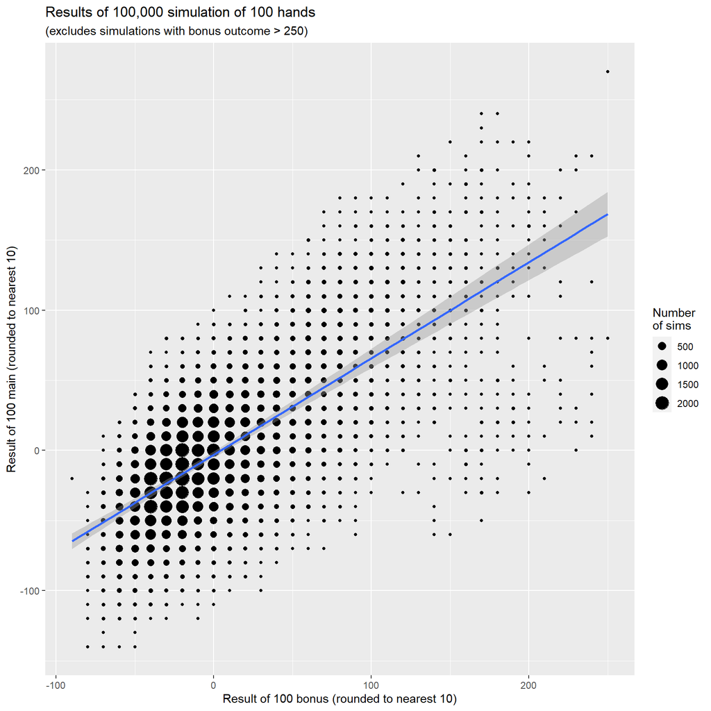

```r
simAll100k100 %>%
    filter(resBonus <= 250) %>%
    mutate(resAllRound=round(resAll, -1), resBonusRound=round(resBonus, -1)) %>%
    count(resAllRound, resBonusRound) %>%
    ggplot(aes(x=resBonusRound, y=resAllRound)) +
    geom_point(aes(size=n)) +
    geom_smooth(method="lm", aes(weight=n)) +
    labs(title="Results of 100,000 simulation of 100 hands",
         subtitle="(excludes simulations with bonus outcome > 250)",
         x="Result of 100 bonus (rounded to nearest 10)",
         y="Result of 100 main (rounded to nearest 10)"
         ) +
    scale_size_continuous("Number\nof sims")
```

An additional simulation is run with data returned:

```r
# Simulations over 100 hands
set.seed(2023053115)

# Simulate 100 hands 10,000 times
simAll10k100 <- simulateAllBets(nHandsPerSim=100, nSims=10000, groupBySim = FALSE)

# Simulate betting progression
simAll10kRes <- simAll10k100 %>%
    mutate(sim=1 + (row_number()-1) %/% 100,
           hn=row_number()-100*(sim-1),
           resMain=case_when(resAll>0~"win", resAll==0~"tie", resAll<0~"loss", TRUE~"error"),
           txtBonus=case_when(resBonus>0~"win", resBonus==0~"tie", resBonus<0~"loss", TRUE~"error")
           ) %>%
    group_by(sim) %>%
    mutate(betMain=ifelse(row_number()<=2 | lag(resMain)=="loss" | lag(resMain, 2)=="loss", 10, 20),
           betBonus=ifelse(row_number()<=2 | lag(txtBonus)=="loss" | lag(txtBonus, 2)=="loss", 5, 10),
           wlMain=betMain*resAll,
           wlBonus=betBonus*resBonus
           ) %>%
    select(sim, resBlind, resAnte, resPlay, resAll, resBonus, wlMain, wlBonus, betMain, betBonus) %>%
    summarize(across(where(is.numeric), sum))

# 1. Overall summary statistics
summary(simAll10kRes)
```

```
##       sim           resBlind         resAnte          resPlay
##  Min.   :    1   Min.   :-66.00   Min.   :-56.00   Min.   :-8.00
##  1st Qu.: 2501   1st Qu.:-40.00   1st Qu.:-33.00   1st Qu.:36.00
##  Median : 5000   Median :-32.00   Median :-27.00   Median :46.00
##  Mean   : 5000   Mean   :-26.11   Mean   :-27.14   Mean   :46.08
##  3rd Qu.: 7500   3rd Qu.:-20.00   3rd Qu.:-21.00   3rd Qu.:56.00
##  Max.   :10000   Max.   :193.00   Max.   :  5.00   Max.   :99.00
##      resAll            resBonus           wlMain            wlBonus
##  Min.   :-124.000   Min.   :-80.000   Min.   :-1350.00   Min.   :-410.00
##  1st Qu.: -32.000   1st Qu.:-32.000   1st Qu.: -410.00   1st Qu.:-165.00
##  Median : -10.000   Median :-14.000   Median : -140.00   Median : -75.00
##  Mean   :  -7.178   Mean   : -6.328   Mean   :  -86.02   Mean   : -32.02
##  3rd Qu.:  13.000   3rd Qu.: 10.000   3rd Qu.:  170.00   3rd Qu.:  55.00
##  Max.   : 220.000   Max.   :975.000   Max.   : 3430.00   Max.   :4860.00
##     betMain        betBonus
##  Min.   :1060   Min.   :500.0
##  1st Qu.:1180   1st Qu.:515.0
##  Median :1210   Median :525.0
##  Mean   :1216   Mean   :524.1
##  3rd Qu.:1250   3rd Qu.:530.0
##  Max.   :1460   Max.   :580.0
```

```r
# 2. Summary of percentiles for main bet and bonus bet
quantile(simAll10kRes$wlMain, c(0, 0.005, 0.01, 0.025, 0.05, 0.25, 0.5, 0.75, 0.95, 0.975, 0.99, 0.995, 1))
```

```
##       0%     0.5%       1%     2.5%       5%      25%      50%      75%
## -1350.00 -1040.00  -950.00  -840.00  -750.00  -410.00  -140.00   170.00
##      95%    97.5%      99%    99.5%     100%
##   750.00  1010.25  1470.10  1820.00  3430.00
```

```r
quantile(simAll10kRes$wlBonus, c(0, 0.005, 0.01, 0.025, 0.05, 0.25, 0.5, 0.75, 0.95, 0.975, 0.99, 0.995, 1))
```

```
##       0%     0.5%       1%     2.5%       5%      25%      50%      75%
## -410.000 -325.025 -310.000 -285.000 -260.000 -165.000  -75.000   55.000
##      95%    97.5%      99%    99.5%     100%
##  335.000  445.000  610.000  780.000 4860.000
```

```r
quantile(simAll10kRes$wlMain+simAll10kRes$wlBonus,
         c(0, 0.005, 0.01, 0.025, 0.05, 0.25, 0.5, 0.75, 0.95, 0.975, 0.99, 0.995, 1)
         )
```

```
##        0%      0.5%        1%      2.5%        5%       25%       50%       75%
## -1600.000 -1275.025 -1185.000 -1050.125  -940.000  -535.000  -210.000   190.000
##       95%     97.5%       99%     99.5%      100%
##   995.250  1365.125  1965.100  2430.000  5730.000
```

```r
# 3. Likelihood of win, lose, tie
simAll10kRes %>%
    mutate(resultType=case_when(wlMain+wlBonus>0 ~ "win", wlMain+wlBonus<0~"lose", TRUE~"tie")) %>%
    group_by(resultType) %>%
    summarize(n=n(), evMain=mean(wlMain), evBonus=mean(wlBonus), .groups="drop") %>%
    mutate(pctSims=n/sum(n))
```

```
## # A tibble: 3 × 5
##   resultType     n evMain evBonus pctSims
##   <chr>      <int>  <dbl>   <dbl>   <dbl>
## 1 lose        6411 -352.   -120.    0.641
## 2 tie           30   32.3   -32.3   0.003
## 3 win         3559  393.    126.    0.356
```

```r
# 4. Correlation of bonus and main bet outcomes
cor(simAll10kRes$wlMain, simAll10kRes$wlBonus)
```

```
## [1] 0.603567
```

```r
cor(simAll10kRes$wlMain, simAll10kRes$wlBonus, method="kendall")
```

```
## [1] 0.3924217
```

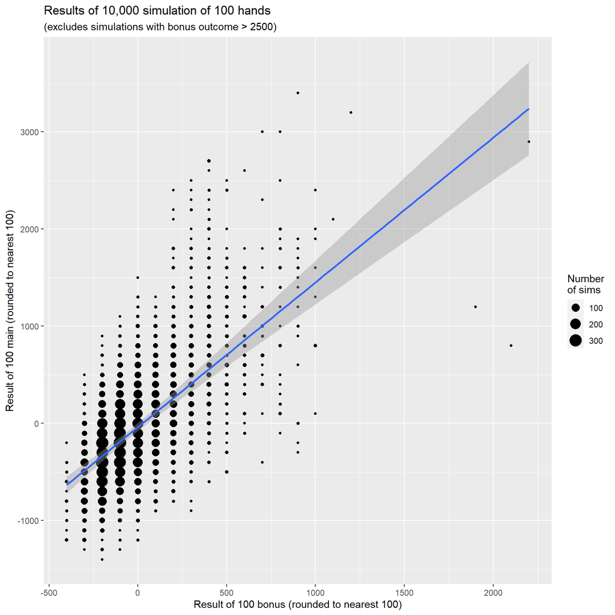

```r
simAll10kRes %>%
    filter(wlBonus <= 2500) %>%
    mutate(resAllRound=round(wlMain, -2), resBonusRound=round(wlBonus, -2)) %>%
    count(resAllRound, resBonusRound) %>%
    ggplot(aes(x=resBonusRound, y=resAllRound)) +
    geom_point(aes(size=n)) +
    geom_smooth(method="lm", aes(weight=n)) +
    labs(title="Results of 10,000 simulation of 100 hands",
         subtitle="(excludes simulations with bonus outcome > 2500)",
         x="Result of 100 bonus (rounded to nearest 100)",
         y="Result of 100 main (rounded to nearest 100)"
         ) +
    scale_size_continuous("Number\nof sims")
```

The average bet sizes by simulation are also explored:

```r
# EV by simulation and bet type
simAll10KSummary <- simAll10kRes %>%
    mutate(bonusPct=wlBonus/betBonus, mainPct=wlMain/betMain)
simAll10KSummary %>%
    select(-sim) %>%
    summarize(across(where(is.numeric), mean)) %>%
    mutate(bonusPct2=wlBonus/betBonus, mainPct2=wlMain/betMain)
```

```
## # A tibble: 1 × 13
##   resBlind resAnte resPlay resAll resBo…¹ wlMain wlBonus betMain betBo…² bonus…³
##      <dbl>   <dbl>   <dbl>  <dbl>   <dbl>  <dbl>   <dbl>   <dbl>   <dbl>   <dbl>
## 1    -26.1   -27.1    46.1  -7.18   -6.33  -86.0   -32.0   1216.    524. -0.0645
## # … with 3 more variables: mainPct <dbl>, bonusPct2 <dbl>, mainPct2 <dbl>, and
## #   abbreviated variable names ¹resBonus, ²betBonus, ³bonusPct
```

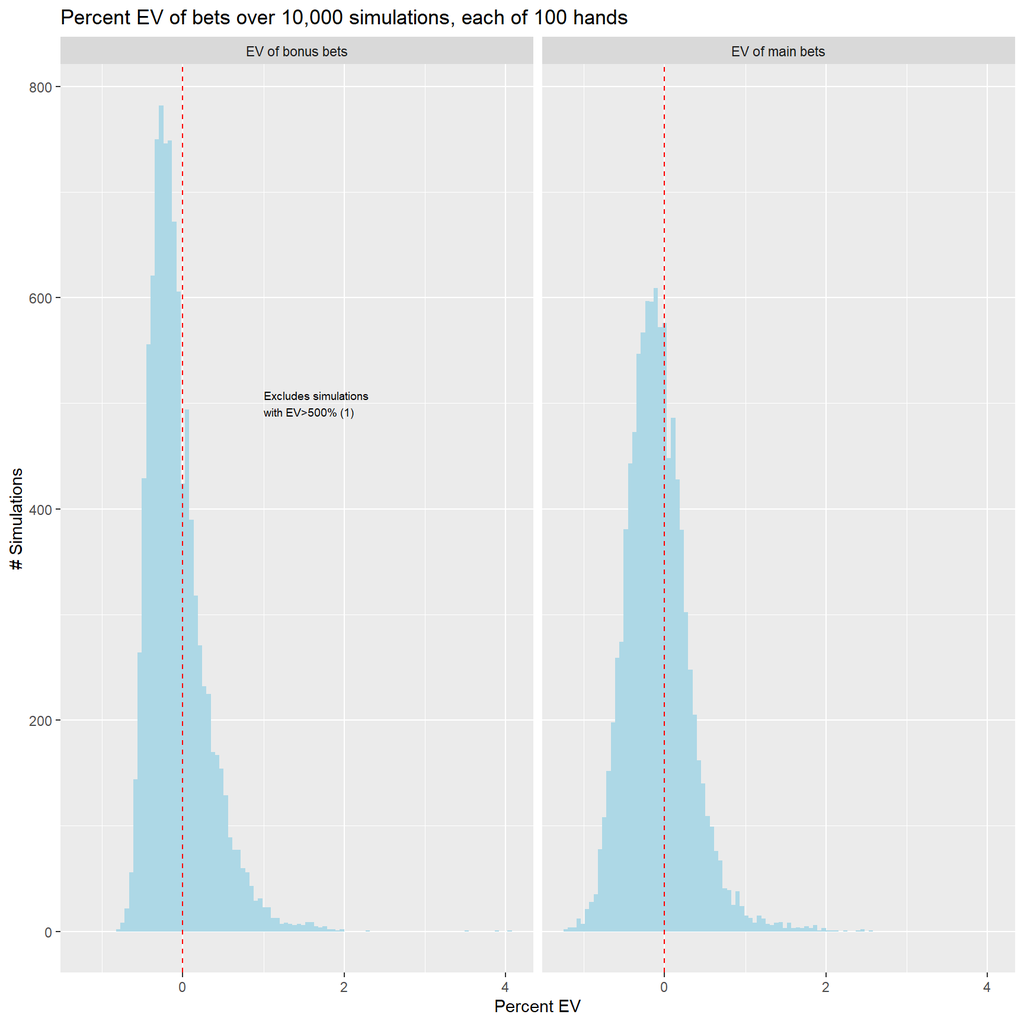

```r
simAll10KSummary %>%
    select(sim, bonusPct, mainPct) %>%
    pivot_longer(cols=-c(sim)) %>%
    ggplot(aes(x=value)) +
    geom_histogram(data=~filter(., value<5), bins=100, fill="lightblue") +
    geom_text(data=~filter(., value>=5) %>% group_by(name) %>% summarize(nSims=n()),
              aes(x=1, y=500, label=paste0("Excludes simulations\nwith EV>500% (", nSims, ")")),
              hjust=0,
              size=2.5
              ) +
    facet_wrap(~c("bonusPct"="EV of bonus bets", "mainPct"="EV of main bets")[name]) +
    geom_vline(xintercept=0, lty=2, color="red") +
    labs(title="Percent EV of bets over 10,000 simulations, each of 100 hands",
         x="Percent EV",
         y="# Simulations"
         )
```

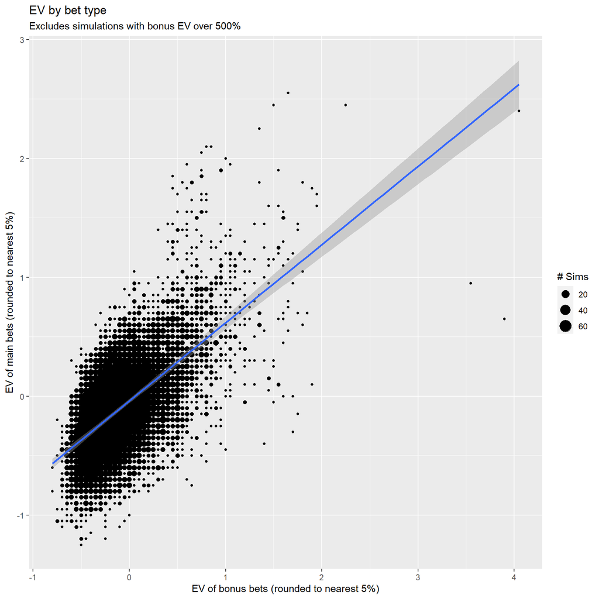

```r
# EV by simulation (excludes EV > 5x)
simAll10kRes %>%
    mutate(bonusPct=round(2*wlBonus/betBonus, 1)/2, mainPct=round(2*wlMain/betMain, 1)/2) %>%
    count(bonusPct, mainPct) %>%
    filter(bonusPct<5) %>%
    ggplot(aes(x=bonusPct, y=mainPct)) +
    geom_point(aes(size=n)) +
    geom_smooth(method="lm", aes(weight=n)) +
    labs(title="EV by bet type",
         subtitle="Excludes simulations with bonus EV over 500%",
         x="EV of bonus bets (rounded to nearest 5%)",
         y="EV of main bets (rounded to nearest 5%)"
         ) +
    scale_size_continuous("# Sims")
```

The minimum and maximum per session are also explored:

```r
simAll10kCumulative <- simAll10k100 %>%
    mutate(sim=1 + (row_number()-1) %/% 100,
           hn=row_number()-100*(sim-1)
           ) %>%
    group_by(sim) %>%
    mutate(cumAll=cumsum(resAll), cumBonus=cumsum(resBonus), cumTotal=15*cumAll+5*cumBonus) %>%
    ungroup()
simAll10kCumulative
```

```
## # A tibble: 1,000,000 × 19
##    handNum  type numDup betPlay name  value resBl…¹ resAnte resPlay resAll    rn
##      <int> <dbl>  <int>   <dbl> <chr> <dbl>   <dbl>   <dbl>   <dbl>  <dbl> <int>
##  1 1377719    11     24       1 pWN   0.262       0       0       1      1     1
##  2  773382    11     24       2 pWN   0.261       0       0       2      2     2
##  3 1237442    11     24       2 pLQ   0.412      -1      -1      -2     -4     3
##  4 1212728    11     24       1 pWN   0.262       0       0       1      1     4
##  5  357537     8     60       2 pWN   0.298       2       0       2      4     5
##  6 1516918    10     24       2 pWQ   0.477       0       1       2      3     6
##  7  583516    11     24       1 pWN   0.261       0       0       1      1     7
##  8  810699    11     24       1 pLQ   0.630      -1      -1      -1     -3     8
##  9  360378    11     60       2 pWN   0.298       0       0       2      2     9
## 10 1664023    11     24       1 pWN   0.261       0       0       1      1    10
## # … with 999,990 more rows, 8 more variables: resBonus <dbl>, n <int>,
## #   pct <dbl>, sim <dbl>, hn <dbl>, cumAll <dbl>, cumBonus <dbl>,
## #   cumTotal <dbl>, and abbreviated variable name ¹resBlind
```

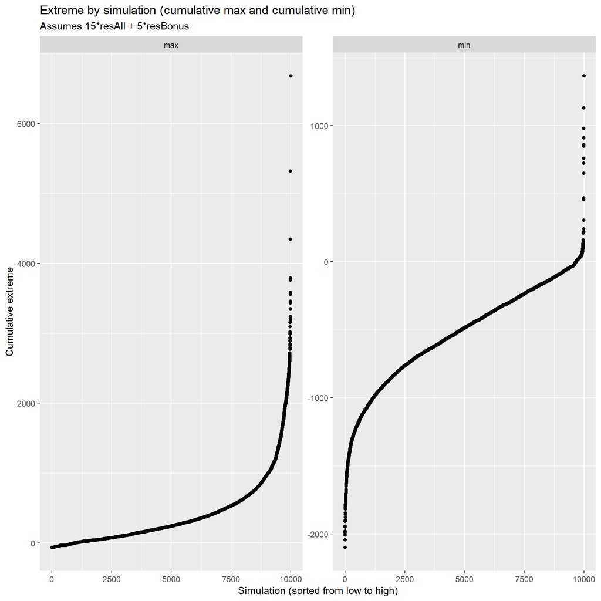

```r
# Calculate highs and lows by simulation
simAll10kCumulative %>%
    select(sim, cumAll, cumBonus, cumTotal) %>%
    group_by(sim) %>%
    summarize(across(starts_with("cum"), .fns=list(min=min, max=max))) %>%
    pivot_longer(cols=-sim) %>%
    mutate(betType=str_split_i(name, pattern="_", i=1),
           betMetric=str_split_i(name, pattern="_", i=2)
           ) %>%
    filter(betType=="cumTotal") %>%
    arrange(value) %>%
    group_by(betMetric) %>%
    mutate(idx=row_number()) %>%
    ungroup() %>%
    ggplot(aes(x=idx, y=value)) +
    geom_point() +
    facet_wrap(~betMetric, scales="free_y") +
    labs(y="Cumulative extreme",
         x="Simulation (sorted from low to high)",
         title="Extreme by simulation (cumulative max and cumulative min)",
         subtitle="Assumes 15*resAll + 5*resBonus"
         )
```

The minimum vs. final result is also plotted:

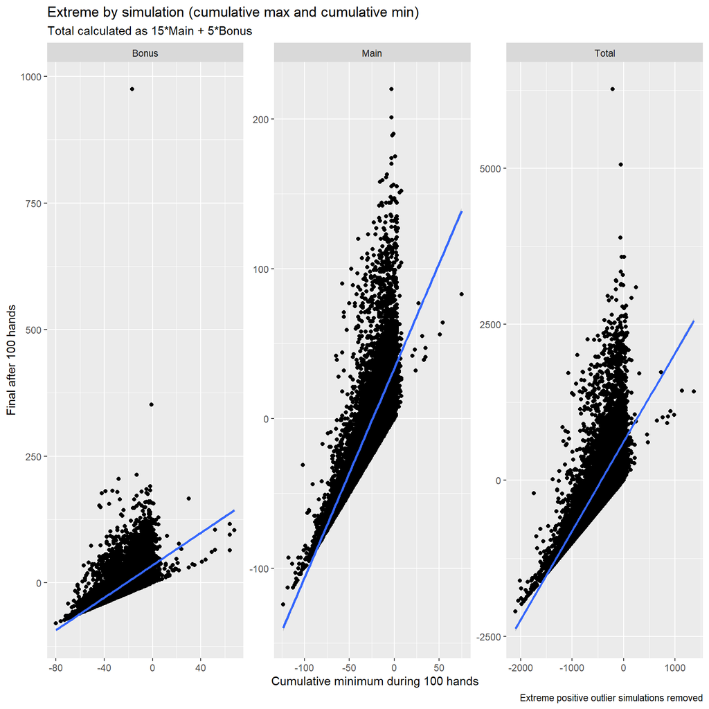

```r
# Minimum vs. final result
simAll10kCumulative %>%
    select(sim, cumAll, cumBonus, cumTotal) %>%
    group_by(sim) %>%
    summarize(across(starts_with("cum"), .fns=list(min=min, last=last))) %>%
    pivot_longer(cols=-sim) %>%
    mutate(betType=str_split_i(name, pattern="_", i=1),
           betMetric=str_split_i(name, pattern="_", i=2)
           ) %>%
    pivot_wider(id_cols=c("sim", "betType"), names_from="betMetric", values_from="value") %>%
    filter((betType %in% c("cumAll", "cumBonus") & last < 1000) | (betType=="cumTotal" & last < 10000)) %>%
    mutate(betType=ifelse(betType=="cumAll", "cumMain", betType)) %>%
    ggplot(aes(x=min, y=last)) +
    geom_point() +
    geom_smooth(method="lm") +
    facet_wrap(~stringr::str_replace(betType, "cum", ""), scales="free") +
    labs(y="Final after 100 hands",
         x="Cumulative minimum during 100 hands",
         title="Extreme by simulation (cumulative max and cumulative min)",
         subtitle="Total calculated as 15*Main + 5*Bonus",
         caption="Extreme positive outlier simulations removed"
         )
```